# Analyze: How do Casual Users and Annual Subscribers Differ?

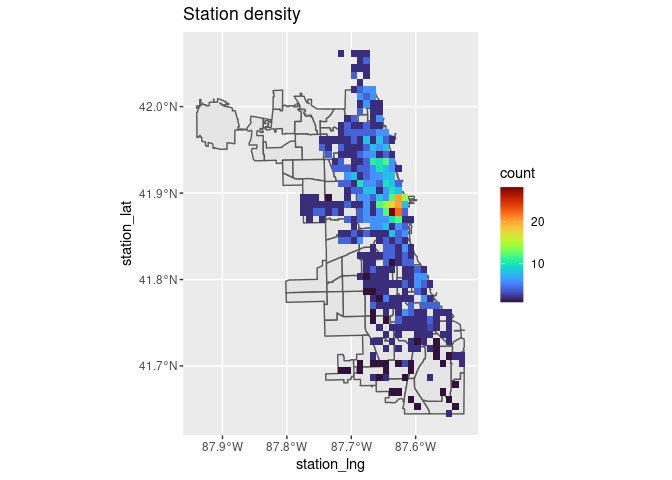

[figure not shown]

[figure not shown]

[figure not shown]

[figure not shown]

[figure not shown]

[figure not shown]

[figure not shown]

[figure not shown]

```r
# Let bin2d perform the binning and give us a heatmap
ggplot(boundaries_chi, aes()) +
  geom_sf() +
  geom_bin2d(data = stations, mapping = aes(station_lng, station_lat), bins=c(25,50)) +
  scale_fill_viridis(option= 'turbo') +
  labs(title = 'Station density')
```

### Zoom in

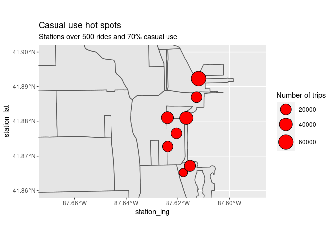

### Which stations are these?

These stations are all on and around the waterfront between Soldier Field and Navy Pier.

```r
stations_users %>%
  slice_max(n_trips_casual, n = 10) %>%
  arrange(desc(n_trips_casual)) %>%
  select(start_station_name, n_trips_casual, n_trips_station, p_trips_casual, station_lng, station_lat)
```

```
## # A tibble: 26 × 7
## # Groups:   start_station_id [26]
##    start_station_id start_station_name        n_trips_casual n_trips_station
##    <fct>            <fct>                              <int>           <int>
##  1 35               Streeter Dr & Grand Ave            47106           60903
##  2 76               Lake Shore Dr & Monroe St          32854           45142
##  3 90               Millennium Park                    29735           36742
##  4 3                Shedd Aquarium                     16636           22112
##  5 2                Buckingham Fountain                15632           18812
##  6 623              Michigan Ave & 8th St              14120           19543
##  7 6                Dusable Harbor                     13300           18977
##  8 13029            Field Museum                        4239            5648
##  9 406              Lake Park Ave & 35th St             3602            5099
## 10 200              MLK Jr Dr & 47th St                 1028            1028
## # … with 16 more rows, and 3 more variables: p_trips_casual <dbl>,
## #   station_lng <dbl>, station_lat <dbl>
```

## Average rider motion by hour

Here we’ll examine the overall traffic flow: as the hours go by, do riders tend to ride in a particular direction? **Yes!** Overall it seems like there is a daily tendency for riders (and bicycles) to move northwest.

### TODO: make interpretable with distance

This has connections with how Divvy may have to shuttle bikes around at night to ensure the busy stations have bikes.

```r
angle_from_x_axis <- function(y,x) {
  angle <- atan(y/x)
  if (x<0) {
    angle <- angle + pi
  } else if (x>=0 & y<0) {
    angle <- angle + 2*pi
  }
  angle * 180 / pi
}
# trend over the entire dataset
overall_vec <- df %>%
  group_by(member_casual) %>%
  summarize(x = sum(trip_delta_x),
            y = sum(trip_delta_y),
            mean_x = mean(trip_delta_x),
            mean_y = mean(trip_delta_y),
            magnitude = sqrt(x^2 + y^2),
            angle = angle_from_x_axis(y,x))
overall_vec
```

```
## # A tibble: 2 × 7
##   member_casual       x      y  mean_x mean_y magnitude angle
##   <fct>           <dbl>  <dbl>   <dbl>  <dbl>     <dbl> <dbl>
## 1 casual        -52573. 90083. -0.0267 0.0458   104302.  120.
## 2 member        -52795. 62331. -0.0202 0.0239    81685.  130.
```

The overall trend is for trips to go northwest. The averaged traffic flow over the dataset represents about 200,000km of travel to the northwest.

## Monthly variation

```r
# monthly trends
month_vec <- df %>%
  group_by(member_casual,
           month = lubridate::month(started_at)) %>%
  summarize(x = sum(trip_delta_x),
            y = sum(trip_delta_y),
            mean_x = mean(trip_delta_x),
            mean_y = mean(trip_delta_y),
            magnitude = sqrt(x^2 + y^2),
            angle = angle_from_x_axis(y,x))
```

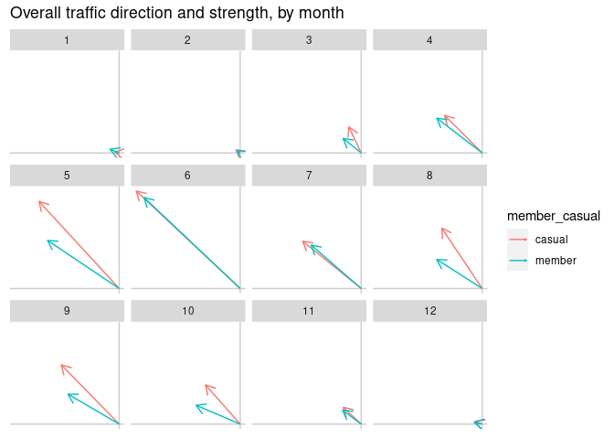

```r
ggplot(month_vec, aes(x=0, y=0, xend=x, yend=y, color=member_casual)) +
  geom_hline(yintercept = 0, color = 'gray80') +
  geom_vline(xintercept = 0, color = 'gray80') +
  theme_gray() +
  theme(axis.text = element_blank(),
        axis.title = element_blank(),
        axis.ticks = element_blank(),
        panel.background = element_blank()) +
  geom_segment(arrow = arrow(length = unit(0.1, "npc"))) +
  facet_wrap(~month) +
  labs(title = "Overall traffic direction and strength, by month")
```

The overall traffic flow for members and casuals is pretty similar. Over the months only the volume has a large change. We’ll have to break the data down further to gain more insight.

## Weekday variation

```r
# monthly trends
weekday_vec <- df %>%
  group_by(member_casual, weekday) %>%
  summarize(x = sum(trip_delta_x),
            y = sum(trip_delta_y),
            mean_x = mean(trip_delta_x),
            mean_y = mean(trip_delta_y),
            magnitude = sqrt(x^2 + y^2),
            angle = angle_from_x_axis(y,x))
```

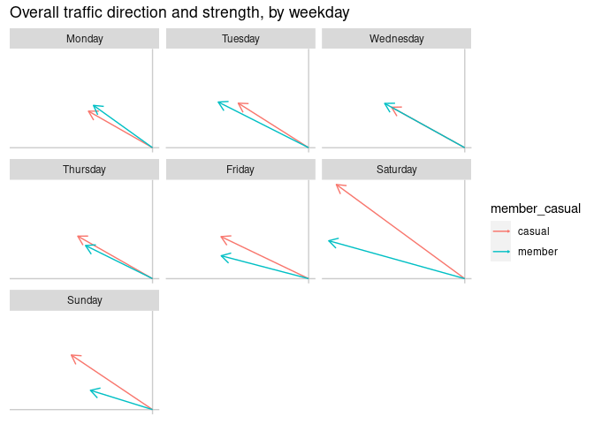

```r
ggplot(weekday_vec, aes(x=0, y=0, xend=x, yend=y, color=member_casual)) +
  geom_hline(yintercept = 0, color = 'gray80') +
  geom_vline(xintercept = 0, color = 'gray80') +
  theme_gray() +
  theme(axis.text = element_blank(),
        axis.title = element_blank(),
        axis.ticks = element_blank(),
        panel.background = element_blank()) +
  geom_segment(arrow = arrow(length = unit(0.1, "npc"))) +
  facet_wrap(~weekday) +
  labs(title = "Overall traffic direction and strength, by weekday")
```

Casuals show the biggest change from the “commuting” pattern on the weekend. Still, this is not very insightful. We’ll continue to break down the traffic flow.

## Hourly variation

We compute an estimate of the overall flow of traffic (direction and distance) for every trip taken each hour. We see the strong signals for the morning and evening commutes, with the evening being larger. This probably leads to bicycles being distributed over the city unequally, with a bias towards the northwest.

*Technical note: This is done by adding the vectors of every trip up to compute the ‘overall trip’ during that hour*

```r
# monthly trends
hourly_vec <- df %>%
  group_by(member_casual, hour = lubridate::hour(started_at)) %>%
  summarize(x = sum(trip_delta_x),
            y = sum(trip_delta_y),
            mean_x = mean(trip_delta_x),
            mean_y = mean(trip_delta_y),
            magnitude = sqrt(x^2 + y^2),
            angle = angle_from_x_axis(y,x))
```

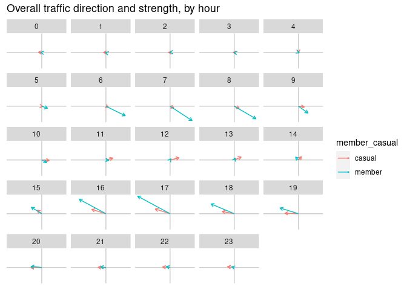

```r
ggplot(hourly_vec, aes(x=0, y=0, xend=x, yend=y, color=member_casual)) +
  geom_hline(yintercept = 0, color = 'gray80') +
  geom_vline(xintercept = 0, color = 'gray80') +
  theme_gray() +
  theme(axis.text = element_blank(),
        axis.title = element_blank(),
        axis.ticks = element_blank(),
        panel.background = element_blank()) +
  geom_segment(arrow = arrow(length = unit(0.1, "npc"))) +
  facet_wrap(~hour) +
  labs(title = "Overall traffic direction and strength, by hour")
```

That’s interesting. Over 24 hours, the overall traffic flow rotates, grows, and shrinks a lot. Between 6-8am we see the morning commute, and between 4-6pm there is a similar signal in the opposite direction for the evening commute. It appears the evening commute is larger. It’s also interesting to note that casual traffic is actually larger than member traffic between the hours of 11am and 1pm.

Still, there isn’t a large difference between casuals and members. Let’s break it down further.

```r
# monthly trends
month_weekday_vec <- df %>%
  group_by(member_casual,
           month = lubridate::month(started_at, label = TRUE),
           weekday) %>%
  summarize(x = sum(trip_delta_x),
            y = sum(trip_delta_y),
            mean_x = mean(trip_delta_x),
            mean_y = mean(trip_delta_y),
            magnitude = sqrt(x^2 + y^2),
            angle = angle_from_x_axis(y,x))
```

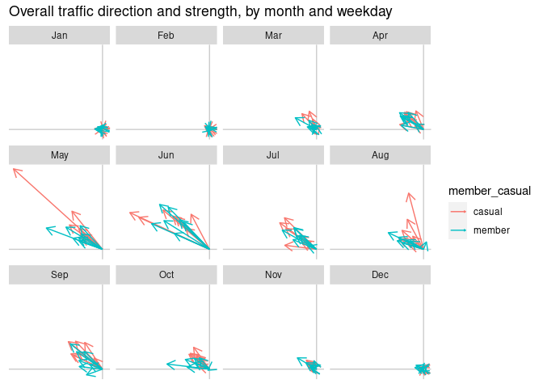

```r
ggplot(month_weekday_vec, aes(x=0, y=0, xend=x, yend=y, color=member_casual)) +
  geom_hline(yintercept = 0, color = 'gray80') +
  geom_vline(xintercept = 0, color = 'gray80') +
  theme_gray() +
  theme(axis.text = element_blank(),
        axis.title = element_blank(),
        axis.ticks = element_blank(),
        panel.background = element_blank()) +
  geom_segment(arrow = arrow(length = unit(0.1, "npc"))) +
  facet_wrap(~month) +
  labs(title = "Overall traffic direction and strength, by month and weekday")
```

There is a large signal in May for casual users. Let’s investigate.

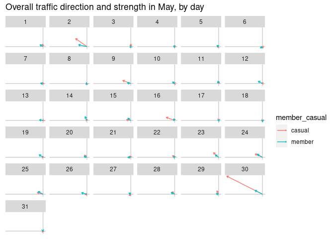

```r
df %>%
  mutate(daynum = lubridate::day(started_at)) %>%
  filter(lubridate::month(started_at) == 5,
         lubridate::year(started_at) == 2020) %>%
  group_by(member_casual, daynum) %>%
  summarize(x = sum(trip_delta_x),
            y = sum(trip_delta_y),
            mean_x = mean(trip_delta_x),
            mean_y = mean(trip_delta_y),
            magnitude = sqrt(x^2 + y^2),
            angle = angle_from_x_axis(y,x)) %>%
  ggplot(aes(x=0, y=0, xend=x, yend=y, color=member_casual)) +
  geom_hline(yintercept = 0, color = 'gray80') +
  geom_vline(xintercept = 0, color = 'gray80') +
  theme_gray() +
  theme(axis.text = element_blank(),
        axis.title = element_blank(),
        axis.ticks = element_blank(),
        panel.background = element_blank()) +
  geom_segment(arrow = arrow(length = unit(0.1, "npc"))) +
  facet_wrap(~daynum) +
  labs(title = "Overall traffic direction and strength in May, by day")
```

There is a huge signal on May 30, 2020 and near-zero activity the following day.

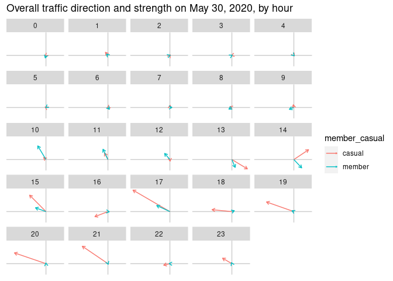

```r
df %>%
  mutate(hour = lubridate::hour(started_at)) %>%
  filter(lubridate::month(started_at) == 5,
         lubridate::day(started_at) == 30,
         lubridate::year(started_at) == 2020) %>%
  group_by(member_casual, hour) %>%
  summarize(x = sum(trip_delta_x),
            y = sum(trip_delta_y),
            mean_x = mean(trip_delta_x),
            mean_y = mean(trip_delta_y),
            magnitude = sqrt(x^2 + y^2),
            angle = angle_from_x_axis(y,x)) %>%
  ggplot(aes(x=0, y=0, xend=x, yend=y, color=member_casual)) +
  geom_hline(yintercept = 0, color = 'gray80') +
  geom_vline(xintercept = 0, color = 'gray80') +
  theme_gray() +
  theme(axis.text = element_blank(),
        axis.title = element_blank(),
        axis.ticks = element_blank(),
        panel.background = element_blank()) +
  geom_segment(arrow = arrow(length = unit(0.1, "npc"))) +
  facet_wrap(~hour) +
  labs(title = "Overall traffic direction and strength on May 30, 2020, by hour")
```

Most of the activity starts after 3pm. Searching the internet, we find that May 30 2020 was the date of a massive *Black Lives Matter* protest in Chicago. It seems many people used the bikes to get to and from the protests. The following day under guidance from the city, Divvy shut down the bike share service at 4pm.

[Reference:](https://chicago.cbslocal.com/2020/05/31/divvy-bikes-to-close-system-at-4-p-m-amid-unrest-in-chicago/)

## Hourly and daily patterns

Let’s examine the difference in overall traffic flow over each hour in a week, and compare members vs casual users.

```r
# day-of-the-week plus hour trends
dow_hour_vec <- df %>%
  group_by(member_casual,
           weekday,
           hour = lubridate::hour(started_at)) %>%
  summarize(x = sum(trip_delta_x),
            y = sum(trip_delta_y),
            mean_x = mean(trip_delta_x),
            mean_y = mean(trip_delta_y),
            magnitude = sqrt(x^2 + y^2),
            angle = angle_from_x_axis(y,x))
```

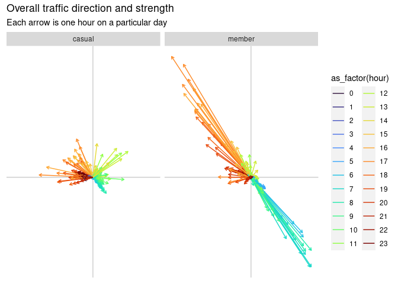

```r
ggplot(dow_hour_vec, aes(x=0, y=0, xend=x, yend=y, color=as_factor(hour))) +
  geom_hline(yintercept = 0, color = 'gray80') +
  geom_vline(xintercept = 0, color = 'gray80') +
  theme_gray() +
  theme(axis.text = element_blank(),
        axis.title = element_blank(),
        axis.ticks = element_blank(),
        panel.background = element_blank()) +
  geom_segment(arrow = arrow(length = unit(0.02, "npc"))) +
  facet_wrap(~member_casual) +
  labs(title = "Overall traffic direction and strength",
       subtitle = "Each arrow is one hour on a particular day") +
  scale_color_viridis(discrete = TRUE, option="turbo")
```

We see the members commuting signal very strongly here. Casual users also have patterns visible:

- On the weekends there seems to be traffic flowing northeast and west at different times of the day.
- During the week there is a weak signal that corresponds with the typical commuting directions.

Let’s break this down further and split the trips into weekends vs weekdays.

```r
# day-of-the-week plus hour and weekend flag
wewd_hour_vec <- df %>%
  group_by(member_casual,
           weekend_weekday,
           weekday,
           hour = lubridate::hour(started_at)) %>%
  summarize(x = sum(trip_delta_x),
            y = sum(trip_delta_y),
            mean_x = mean(trip_delta_x),
            mean_y = mean(trip_delta_y),
            magnitude = sqrt(x^2 + y^2),
            angle = angle_from_x_axis(y,x))
```

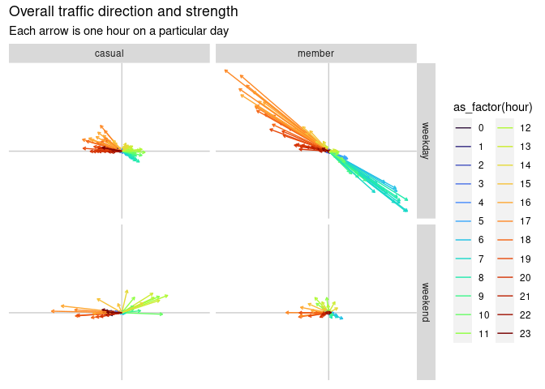

```r
ggplot(wewd_hour_vec, aes(x=0, y=0, xend=x, yend=y, color=as_factor(hour))) +
  geom_hline(yintercept = 0, color = 'gray80') +
  geom_vline(xintercept = 0, color = 'gray80') +
  theme_gray() +
  theme(axis.text = element_blank(),
        axis.title = element_blank(),
        axis.ticks = element_blank(),
        panel.background = element_blank()) +
  geom_segment(arrow = arrow(length = unit(0.02, "npc"))) +
  facet_grid(cols = vars(member_casual),
             rows = vars(weekend_weekday)) +
  labs(title = "Overall traffic direction and strength",
       subtitle = "Each arrow is one hour on a particular day") +
  scale_color_viridis(discrete = TRUE, option="turbo")
```

Things become clearer. During the week, casual traffic follows the same pattern as members, suggesting that many of these trips are actually for commuting.

Let’s examine casual traffic flow only.

```r
# hourly trends for weekday vs weekend
weekend_hour_vecs <- df %>%
  group_by(member_casual,
           weekend_weekday,
           hour = lubridate::hour(started_at)) %>%
  summarize(x = sum(trip_delta_x),
            y = sum(trip_delta_y),
            mean_x = mean(trip_delta_x),
            mean_y = mean(trip_delta_y),
            magnitude = sqrt(x^2 + y^2),
            angle = angle_from_x_axis(y,x))
```

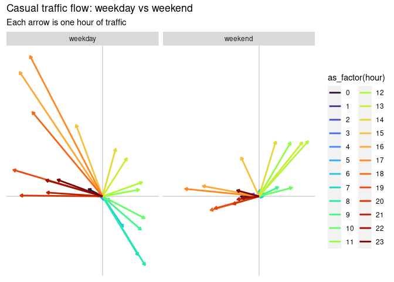

```r
weekend_hour_vecs %>%
  filter(member_casual == 'casual') %>%
  ggplot(aes(x=0, y=0, xend=x, yend=y, color=as_factor(hour))) +
  geom_hline(yintercept = 0, color = 'gray80') +
  geom_vline(xintercept = 0, color = 'gray80') +
  theme_gray() +
  theme(axis.text = element_blank(),
        axis.title = element_blank(),
        axis.ticks = element_blank(),
        panel.background = element_blank()) +
  geom_segment(arrow = arrow(length = unit(0.02, "npc")), size=1) +
  facet_wrap(~weekend_weekday) +
  labs(title = "Casual traffic flow: weekday vs weekend",
       subtitle = "Each arrow is one hour of traffic") +
  scale_color_viridis(discrete = TRUE, option="turbo")
```

We see the commuting pattern during the week, as expected. On the weekend however, many casual trips are taken in the morning to early afternoon, traveling northeast. In the afternoon the overall casual traffic flow swings to the west. Recalling our map of casual hot spots earlier, we suggest that a majority of casual users are taking trips to the waterfront, spending some time there, and then returning home.

## Traffic flow: members vs casuals

Let’s examine many of these patterns all at once, in context so we can compare them to each other.

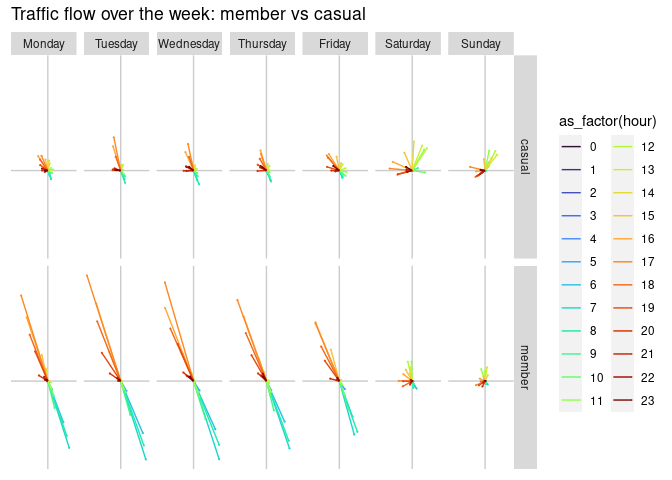

```r
ggplot(dow_hour_vec, aes(x=0, y=0, xend=x, yend=y, color=as_factor(hour))) +
  geom_hline(yintercept = 0, color = 'gray80') +
  geom_vline(xintercept = 0, color = 'gray80') +
  theme_gray() +
  theme(axis.text = element_blank(),
        axis.title = element_blank(),
        axis.ticks = element_blank(),
        panel.background = element_blank()) +
  geom_segment(arrow = arrow(length = unit(0.02, "npc"))) +
  facet_grid(rows = vars(member_casual),
             cols = vars(weekday)) +
  labs(title = "Traffic flow over the week: member vs casual") +
  scale_color_viridis(discrete = TRUE, option="turbo")
```

## TODO

- Bike Motion maps: calculate total “bike miles” moved in a certain direction to make the abstract arrows more concrete.
  - **A grid of arrows like a direction field**: aggregate into rectangles like before, calculate the averate motion per rect and create an arrow, and map all the arrows at the center of the squares!
    - This could be animated by the hour…. giving **a traffic flow like a bed of seagrass flowing in the tide…**
- visualize timelapse behaviour
  - trips starting from a sector, with scrubbable hour (tableau!)
    - or as an animation
  - and similarly, ending at a sector..
- Can you draw a map of LINES connecting start and end points for trips..?
  - or similarly, for e.g. 4-4:59pm, a cloud of dots in two colours, trips started and trips ended, at every location.
- What were the busiest casual days? Holidays? Sports events?
  - Where was the traffic starting and ending?